# Assignment 2.1: School composition and school choice

Author

Mariia Steeghs-Turchina · DV7

## Research question

Among regular Dutch primary schools, is the neighbourhood composition of four-year-old intake associated with that of pupils already enrolled in the previous year, after accounting for where families live?

**Level: inference.** If families respond to a school’s existing composition, a small change in intake could persist. We ask whether the data are consistent with that possibility. They cannot by themselves show that composition causes school choice.

**Target audience.** Education officers concerned with segregation and parents choosing schools. The visualization should connect school-level patterns to those decisions.

## Datasets

We use four public datasets:

- **[DUO pupil origins (2022–2023)](https://onderwijsdata.duo.nl/dataset/4ea91ae5-51ef-48a4-aa67-7098343f75bc):** counts by school location and home postcode (PC4). We use these to calculate each school’s neighbourhood composition.
- **[DUO school totals (2022–2023)](https://onderwijsdata.duo.nl/dataset/cf80e90d-ed19-4a10-a138-00c5c345cb5e):** total enrolment per school location. We use these as the denominator for coverage.
- **[CBS postcode population (2022)](https://opendata.cbs.nl/#/CBS/nl/dataset/83503NED/table):** residents by migration background and PC4. We use these to describe the neighbourhoods linked to pupils’ postcodes.
- **[DUO pupils by age and postcode (2023)](https://duo.nl/open_onderwijsdata/images/03.-leerlingen-po-totaaloverzicht-2023-2024.csv):** counts by age, school, and home postcode. We inspect age-four cells as a possible intake measure and quantify suppression.

## Exploratory process

### Data and cleaning

The download script caches the source files. Functions in `R/` then prepare, inspect, and plot the data.

```r
library(ggplot2)
library(plotly)
library(scales)

source("scripts/download.R")
source("R/prepare.R")
source("R/plots.R")

data <- prepare_data(paths)
intake <- check_intake(paths[["intake"]])
schools_2023 <- filter(data$schools, year == 2023)
selected <- filter(schools_2023, eligible)
#' Format counts with thousands separators.
format_n <- function(x) format(x, big.mark = ",", scientific = FALSE)
```

Each row in the DUO origins data represents one school–postcode–year; each plotted point represents one school. We keep school codes as text, retain regular primary schools in 2022 and 2023, and join CBS to pupils’ home PC4.

The **neighbourhood composition proxy** is the pupil-weighted average of the share of residents in CBS’s historical “non-western migration background” category. Both enrolment years use the 2022 CBS release.

DUO marks suppressed counts as `-1`, we treat them as missing. A postcode enters the weighted average only when its count is exact and CBS reports at least 50 residents. A school is eligible when at least 50 pupils are matched and coverage is at least 80%.

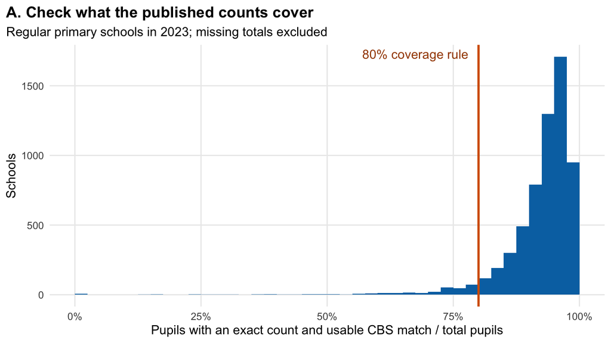

```r
plot_coverage(data$schools)
```

Of 6,150 regular primary school locations in 2023, 3 lack a usable total and 5,656 pass both quality rules. Overall median coverage is 94.4%. Coverage combines count suppression, unusable postcodes, and missing CBS values.

### First patterns

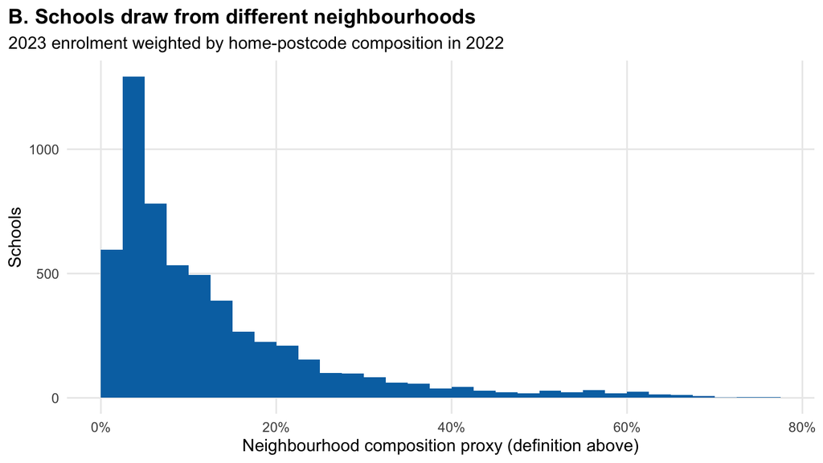

```r
plot_composition(data$schools)
```

The middle half of included schools spans 4.0% to 16.3%. This variation makes the question worth investigating, but may reflect residential segregation and geography as well as school choice.

```r
ggplotly(plot_persistence(data$pairs), tooltip = "text")
```

[interactive chart not shown]

Among 5,536 schools meeting the rules in both years, the median absolute change is 0.07 percentage points. The 7 orange triangles flag changes larger than five points for closer inspection. Large changes could also arise from mergers or changing data coverage.

### Next stage

We also checked DUO’s October 2023 file by age and home postcode. Among 28,607 school–postcode cells with at least one four-year-old, 69.9% are suppressed as `<5`. Age four is a proxy for intake. Small flows will therefore need a defensible treatment before modelling.

- Keep neighbourhood composition as a labelled proxy.
- Examine four-year-old intake separately from existing pupils. Most pupils remain enrolled between years, so persistence in total enrolment is expected.
- Check school continuity and coverage before interpreting large changes.
- For the later inference, account for home-postcode and school differences and existing recruitment links. Show estimated associations with uncertainty; these exploratory plots do not answer the causal question.

### Sources and reproducibility

[DUO pupil origins](https://onderwijsdata.duo.nl/dataset/4ea91ae5-51ef-48a4-aa67-7098343f75bc), [DUO school totals](https://onderwijsdata.duo.nl/dataset/cf80e90d-ed19-4a10-a138-00c5c345cb5e), [DUO pupils by age and postcode](https://duo.nl/open_onderwijsdata/images/03.-leerlingen-po-totaaloverzicht-2023-2024.csv), and [CBS table 83503NED](https://opendata.cbs.nl/#/CBS/nl/dataset/83503NED/table). The first knit downloads these public sources; later knits reuse local copies. The raw data is not committed. Source releases may be revised. Code: thatmariia/bdst_dv.